# 23049287 Nikita Gauli

2. Data Preparation
1. Importing the Dataset

```python
import pandas as pd
```

```python
# Load the CSV file
df = pd.read_csv('Customer Service_Requests_from_2010_to_Present.csv', low_memory=False)
```

1. Data Understanding

The objective of the Data Understanding phase is to gain a comprehensive overview of the dataset’s structure, content, and quality. This includes identifying data types, key variables, missing values, and initial patterns to ensure the dataset is suitable for analysis. It forms the foundation for effective data cleaning, preparation, and modeling in later stages.

```python
# Check shape and columns
print("Shape:", df.shape)
print("\nColumns:\n", df.columns)
```

```
Shape: (300698, 53)

Columns:
 Index(['Unique Key', 'Created Date', 'Closed Date', 'Agency', 'Agency Name',
       'Complaint Type', 'Descriptor', 'Location Type', 'Incident Zip',
       'Incident Address', 'Street Name', 'Cross Street 1', 'Cross Street 2',
       'Intersection Street 1', 'Intersection Street 2', 'Address Type',
       'City', 'Landmark', 'Facility Type', 'Status', 'Due Date',
       'Resolution Description', 'Resolution Action Updated Date',
       'Community Board', 'Borough', 'X Coordinate (State Plane)',
       'Y Coordinate (State Plane)', 'Park Facility Name', 'Park Borough',
       'School Name', 'School Number', 'School Region', 'School Code',
       'School Phone Number', 'School Address', 'School City', 'School State',
       'School Zip', 'School Not Found', 'School or Citywide Complaint',
       'Vehicle Type', 'Taxi Company Borough', 'Taxi Pick Up Location',
       'Bridge Highway Name', 'Bridge Highway Direction', 'Road Ramp',
       'Bridge Highway Segment', 'Garage Lot Name', 'Ferry Direction',
       'Ferry Terminal Name', 'Latitude', 'Longitude', 'Location'],
      dtype='object')
```

```python
# Display first few rows
print("\nSample data:\n", df.head())
```

```
Sample data:
    Unique Key            Created Date    Closed Date Agency  \
0    32310363  12/31/2015 11:59:45 PM  01-01-16 0:55   NYPD
1    32309934  12/31/2015 11:59:44 PM  01-01-16 1:26   NYPD
2    32309159  12/31/2015 11:59:29 PM  01-01-16 4:51   NYPD
3    32305098  12/31/2015 11:57:46 PM  01-01-16 7:43   NYPD
4    32306529  12/31/2015 11:56:58 PM  01-01-16 3:24   NYPD

                       Agency Name           Complaint Type  \
0  New York City Police Department  Noise - Street/Sidewalk
1  New York City Police Department         Blocked Driveway
2  New York City Police Department         Blocked Driveway
3  New York City Police Department          Illegal Parking
4  New York City Police Department          Illegal Parking

```

[output cut: 36 more lines]

```python
# Data types
print("\nData Types:\n", df.dtypes)
```

```
Data Types:
 Unique Key                          int64
Created Date                       object
Closed Date                        object
Agency                             object
Agency Name                        object
Complaint Type                     object
Descriptor                         object
Location Type                      object
Incident Zip                      float64
Incident Address                   object
Street Name                        object
Cross Street 1                     object
Cross Street 2                     object
Intersection Street 1              object
Intersection Street 2              object
Address Type                       object
City                               object
Landmark                           object
Facility Type                      object
Status                             object
Due Date                           object
Resolution Description             object
Resolution Action Updated Date     object
Community Board                    object
Borough                            object
X Coordinate (State Plane)        float64
Y Coordinate (State Plane)        float64
Park Facility Name                 object
Park Borough                       object
School Name                        object
School Number                      object
School Region                      object
School Code                        object
School Phone Number                object
School Address                     object
School City                        object
School State                       object
School Zip                         object
School Not Found                   object
School or Citywide Complaint      float64
Vehicle Type                      float64
Taxi Company Borough              float64
Taxi Pick Up Location             float64
Bridge Highway Name                object
Bridge Highway Direction           object
Road Ramp                          object
Bridge Highway Segment             object
Garage Lot Name                   float64
Ferry Direction                    object
Ferry Terminal Name                object
Latitude                          float64
Longitude                         float64
Location                           object
dtype: object
```

```python
# Null values summary
print("\nMissing Values:\n", df.isnull().sum())
```

```
Missing Values:
 Unique Key                             0
Created Date                           0
Closed Date                         2164
Agency                                 0
Agency Name                            0
Complaint Type                         0
Descriptor                          5914
Location Type                        131
Incident Zip                        2615
Incident Address                   44410
Street Name                        44410
Cross Street 1                     49279
Cross Street 2                     49779
Intersection Street 1             256840
Intersection Street 2             257336
Address Type                        2815
City                                2614
Landmark                          300349
Facility Type                       2171
Status                                 0
Due Date                               3
Resolution Description                 0
Resolution Action Updated Date      2187
Community Board                        0
Borough                                0
X Coordinate (State Plane)          3540
Y Coordinate (State Plane)          3540
Park Facility Name                     0
Park Borough                           0
School Name                            0
School Number                          0
School Region                          1
School Code                            1
School Phone Number                    0
School Address                         0
School City                            0
School State                           0
School Zip                             1
School Not Found                       0
School or Citywide Complaint      300698
Vehicle Type                      300698
Taxi Company Borough              300698
Taxi Pick Up Location             300698
Bridge Highway Name               300455
Bridge Highway Direction          300455
Road Ramp                         300485
Bridge Highway Segment            300485
Garage Lot Name                   300698
Ferry Direction                   300697
Ferry Terminal Name               300696
Latitude                            3540
Longitude                           3540
Location                            3540
dtype: int64
```

```python
# Basic information about the dataset
print("Dataset Info:\n")
df.info()
```

```
Dataset Info:

<class 'pandas.core.frame.DataFrame'>
RangeIndex: 300698 entries, 0 to 300697
Data columns (total 53 columns):
 #   Column                          Non-Null Count   Dtype
---  ------                          --------------   -----
 0   Unique Key                      300698 non-null  int64
 1   Created Date                    300698 non-null  object
 2   Closed Date                     298534 non-null  object
 3   Agency                          300698 non-null  object
 4   Agency Name                     300698 non-null  object
 5   Complaint Type                  300698 non-null  object
 6   Descriptor                      294784 non-null  object
 7   Location Type                   300567 non-null  object
```

[output cut: 47 more lines]

```python
# Preview the first few records
print("\nFirst 5 Records:\n")
print(df.head())
```

```
First 5 Records:

   Unique Key            Created Date    Closed Date Agency  \
0    32310363  12/31/2015 11:59:45 PM  01-01-16 0:55   NYPD
1    32309934  12/31/2015 11:59:44 PM  01-01-16 1:26   NYPD
2    32309159  12/31/2015 11:59:29 PM  01-01-16 4:51   NYPD
3    32305098  12/31/2015 11:57:46 PM  01-01-16 7:43   NYPD
4    32306529  12/31/2015 11:56:58 PM  01-01-16 3:24   NYPD

                       Agency Name           Complaint Type  \
0  New York City Police Department  Noise - Street/Sidewalk
1  New York City Police Department         Blocked Driveway
2  New York City Police Department         Blocked Driveway
3  New York City Police Department          Illegal Parking
4  New York City Police Department          Illegal Parking

                     Descriptor    Location Type  Incident Zip  \
0              Loud Music/Party  Street/Sidewalk       10034.0
1                     No Access  Street/Sidewalk       11105.0
2                     No Access  Street/Sidewalk       10458.0
3  Commercial Overnight Parking  Street/Sidewalk       10461.0
4              Blocked Sidewalk  Street/Sidewalk       11373.0

        Incident Address  ... Bridge Highway Name Bridge Highway Direction  \
0    71 VERMILYEA AVENUE  ...                 NaN                      NaN
1        27-07 23 AVENUE  ...                 NaN                      NaN
2  2897 VALENTINE AVENUE  ...                 NaN                      NaN
3    2940 BAISLEY AVENUE  ...                 NaN                      NaN
4          87-14 57 ROAD  ...                 NaN                      NaN

  Road Ramp Bridge Highway Segment Garage Lot Name Ferry Direction  \
0       NaN                    NaN             NaN             NaN
1       NaN                    NaN             NaN             NaN
2       NaN                    NaN             NaN             NaN
3       NaN                    NaN             NaN             NaN
4       NaN                    NaN             NaN             NaN

  Ferry Terminal Name   Latitude  Longitude  \
0                 NaN  40.865682 -73.923501
1                 NaN  40.775945 -73.915094
2                 NaN  40.870325 -73.888525
3                 NaN  40.835994 -73.828379
4                 NaN  40.733060 -73.874170

                                   Location
0   (40.86568153633767, -73.92350095571744)
1  (40.775945312321085, -73.91509393898605)
2  (40.870324522111424, -73.88852464418646)
3   (40.83599404683083, -73.82837939584206)
4  (40.733059618956815, -73.87416975810375)

[5 rows x 53 columns]
```

```python
# Check how many columns and rows
print(f"\nTotal Rows: {df.shape[0]}")
print(f"Total Columns: {df.shape[1]}")
```

```
Total Rows: 300698
Total Columns: 53
```

```python
# List all column names
print("\nList of Columns:")
print(df.columns.tolist())
```

```
List of Columns:
['Unique Key', 'Created Date', 'Closed Date', 'Agency', 'Agency Name', 'Complaint Type', 'Descriptor', 'Location Type', 'Incident Zip', 'Incident Address', 'Street Name', 'Cross Street 1', 'Cross Street 2', 'Intersection Street 1', 'Intersection Street 2', 'Address Type', 'City', 'Landmark', 'Facili…
```

```python
# Count missing values in each column
print("\nMissing Values per Column:")
print(df.isna().sum())
```

```
Missing Values per Column:
Unique Key                             0
Created Date                           0
Closed Date                         2164
Agency                                 0
Agency Name                            0
Complaint Type                         0
Descriptor                          5914
Location Type                        131
Incident Zip                        2615
Incident Address                   44410
Street Name                        44410
Cross Street 1                     49279
Cross Street 2                     49779
Intersection Street 1             256840
Intersection Street 2             257336
Address Type                        2815
City                                2614
Landmark                          300349
Facility Type                       2171
Status                                 0
Due Date                               3
Resolution Description                 0
Resolution Action Updated Date      2187
Community Board                        0
Borough                                0
X Coordinate (State Plane)          3540
Y Coordinate (State Plane)          3540
Park Facility Name                     0
Park Borough                           0
School Name                            0
School Number                          0
School Region                          1
School Code                            1
School Phone Number                    0
School Address                         0
School City                            0
School State                           0
School Zip                             1
School Not Found                       0
School or Citywide Complaint      300698
Vehicle Type                      300698
Taxi Company Borough              300698
Taxi Pick Up Location             300698
Bridge Highway Name               300455
Bridge Highway Direction          300455
Road Ramp                         300485
Bridge Highway Segment            300485
Garage Lot Name                   300698
Ferry Direction                   300697
Ferry Terminal Name               300696
Latitude                            3540
Longitude                           3540
Location                            3540
dtype: int64
```

2. Data Preparation

The objective of this phase is to prepare and clean the dataset for analysis by importing it, understanding its structure, and performing key preprocessing steps. This includes exploring the information carried by each column, converting date fields to proper datetime formats, calculating the request closing time, and removing irrelevant or unnecessary columns. Additionally, handling missing values and checking for unique values across columns ensures the dataset is consistent, clean, and ready for statistical analysis and modeling.

2. Insight into the Dataset

```python
# Get the number of unique values in each column
print("\nUnique Values in Each Column:")
for col in df.columns:
    print(f"{col}: {df[col].nunique()}")
```

```
Unique Values in Each Column:
Unique Key: 300698
Created Date: 259493
Closed Date: 237165
Agency: 1
Agency Name: 3
Complaint Type: 24
Descriptor: 45
Location Type: 18
Incident Zip: 201
Incident Address: 107652
Street Name: 7320
Cross Street 1: 5982
Cross Street 2: 5823
Intersection Street 1: 4413
Intersection Street 2: 4172
Address Type: 5
City: 53
Landmark: 116
Facility Type: 1
Status: 4
Due Date: 259851
Resolution Description: 18
Resolution Action Updated Date: 237895
Community Board: 75
Borough: 6
X Coordinate (State Plane): 63226
Y Coordinate (State Plane): 73694
Park Facility Name: 2
Park Borough: 6
School Name: 2
School Number: 2
School Region: 1
School Code: 1
School Phone Number: 2
School Address: 2
School City: 2
School State: 2
School Zip: 1
School Not Found: 1
School or Citywide Complaint: 0
Vehicle Type: 0
Taxi Company Borough: 0
Taxi Pick Up Location: 0
Bridge Highway Name: 29
Bridge Highway Direction: 34
Road Ramp: 2
Bridge Highway Segment: 160
Garage Lot Name: 0
Ferry Direction: 1
Ferry Terminal Name: 2
Latitude: 125122
Longitude: 125216
Location: 126048
```

```python
# Show top 5 most common complaint types
print("\nTop 5 Most Common Complaint Types:")
print(df['Complaint Type'].value_counts().head())
```

```
Top 5 Most Common Complaint Types:
Complaint Type
Blocked Driveway           77044
Illegal Parking            75361
Noise - Street/Sidewalk    48612
Noise - Commercial         35577
Derelict Vehicle           17718
Name: count, dtype: int64
```

```python
# Show top 5 boroughs by frequency
print("\nTop 5 Boroughs with Most Complaints:")
print(df['Borough'].value_counts().head())
```

```
Top 5 Boroughs with Most Complaints:
Borough
BROOKLYN         98307
QUEENS           80641
MANHATTAN        66131
BRONX            40702
STATEN ISLAND    12343
Name: count, dtype: int64
```

3. Converting Date Columns and Calculating Request Duration

```python
# Convert 'Created Date' and 'Closed Date' to datetime with flexible formats
date_formats = ['%m/%d/%Y %I:%M:%S %p', '%m-%d-%y %H:%M']
df['Created Date'] = pd.to_datetime(df['Created Date'], format=date_formats[0], errors='coerce') \
                        .fillna(pd.to_datetime(df['Created Date'], format=date_formats[1], errors='coerce'))

df['Closed Date'] = pd.to_datetime(df['Closed Date'], format=date_formats[0], errors='coerce') \
                        .fillna(pd.to_datetime(df['Closed Date'], format=date_formats[1], errors='coerce'))

# Create 'Request_Closing_Time' as time difference
df['Request_Closing_Time'] = df['Closed Date'] - df['Created Date']

# Convert timedelta to total hours (you can use seconds instead if you prefer)
df['Request_Closing_Time'] = df['Request_Closing_Time'].dt.total_seconds() / 3600  # hours

# Display the first few rows to verify
print("\nFirst few rows after converting date columns and adding 'Request_Closing_Time':")
print(df[['Created Date', 'Closed Date', 'Request_Closing_Time']].head())
```

```
First few rows after converting date columns and adding 'Request_Closing_Time':
         Created Date         Closed Date  Request_Closing_Time
0 2015-12-31 23:59:45 2016-01-01 00:55:00              0.920833
1 2015-12-31 23:59:44 2016-01-01 01:26:00              1.437778
2 2015-12-31 23:59:29 2016-01-01 04:51:00              4.858611
3 2015-12-31 23:57:46 2016-01-01 07:43:00              7.753889
4 2015-12-31 23:56:58 2016-01-01 03:24:00              3.450556
```

4. Dropping Irrelevant Columns

```python
# List of irrelevant columns to drop
columns_to_drop = ['Agency Name', 'Incident Address', 'Street Name', 'Cross Street 1', 'Cross Street 2',
                   'Intersection Street 1', 'Intersection Street 2', 'Address Type', 'Park Facility Name',
                   'Park Borough', 'School Name', 'School Number', 'School Region', 'School Code',
                   'School Phone Number', 'School Address', 'School City', 'School State', 'School Zip',
                   'School Not Found', 'School or Citywide Complaint', 'Vehicle Type', 'Taxi Company Borough',
                   'Taxi Pick Up Location', 'Bridge Highway Name', 'Bridge Highway Direction', 'Road Ramp',
                   'Bridge Highway Segment', 'Garage Lot Name', 'Ferry Direction', 'Ferry Terminal Name',
                   'Landmark', 'X Coordinate (State Plane)', 'Y Coordinate (State Plane)', 'Due Date',
                   'Resolution Action Updated Date', 'Community Board', 'Facility Type', 'Location']

# Check which columns are present in the dataframe
columns_present = [col for col in columns_to_drop if col in df.columns]

# Drop the irrelevant columns that are present in the dataframe
df = df.drop(columns=columns_present)

# Display the first few rows to verify the changes
print("\nFirst few rows after dropping irrelevant columns:")
print(df.head())
```

```
First few rows after dropping irrelevant columns:
   Unique Key        Created Date         Closed Date Agency  \
0    32310363 2015-12-31 23:59:45 2016-01-01 00:55:00   NYPD
1    32309934 2015-12-31 23:59:44 2016-01-01 01:26:00   NYPD
2    32309159 2015-12-31 23:59:29 2016-01-01 04:51:00   NYPD
3    32305098 2015-12-31 23:57:46 2016-01-01 07:43:00   NYPD
4    32306529 2015-12-31 23:56:58 2016-01-01 03:24:00   NYPD

            Complaint Type                    Descriptor    Location Type  \
0  Noise - Street/Sidewalk              Loud Music/Party  Street/Sidewalk
1         Blocked Driveway                     No Access  Street/Sidewalk
2         Blocked Driveway                     No Access  Street/Sidewalk
3          Illegal Parking  Commercial Overnight Parking  Street/Sidewalk
4          Illegal Parking              Blocked Sidewalk  Street/Sidewalk

```

[output cut: 20 more lines]

5. Handling Missing Values

```python
# Store shape before dropping NaN values
rows_before, cols_before = df.shape

# Drop rows with NaN values
df_cleaned = df.dropna()

# Store shape after dropping NaN values
rows_after, cols_after = df_cleaned.shape

# Display results
print(f"\nBefore removing NaNs: {rows_before} rows, {cols_before} columns")
print(f"After removing NaNs:  {rows_after} rows, {cols_after} columns")
print(f"Total rows removed:   {rows_before - rows_after}")

# Check if any rows were actually removed
if rows_before == rows_after:
    print("\n No rows were removed — the DataFrame has no NaN values.")
else:
    print("\n NaN values removed successfully.")

# Optional: Update the original DataFrame
df = df_cleaned
```

```
Before removing NaNs: 300698 rows, 15 columns
After removing NaNs:  291107 rows, 15 columns
Total rows removed:   9591

 NaN values removed successfully.
```

6. Viewing Unique Values from Columns

```python
# This code displays the number and list of unique values in each column of the dataset,
# helping to understand data distribution, detect categorical features, and spot anomalies.

print("\nUnique Values in Each Column:")
for col in df.columns:
    unique_vals = df[col].unique()
    print(f"\nColumn: {col} ({len(unique_vals)} unique values)")
    print(unique_vals)
```

```
Unique Values in Each Column:

Column: Unique Key (291107 unique values)
[32310363 32309934 32309159 ... 30283424 30280004 30281825]

Column: Created Date (251970 unique values)
<DatetimeArray>
['2015-12-31 23:59:45', '2015-12-31 23:59:44', '2015-12-31 23:59:29',
 '2015-12-31 23:57:46', '2015-12-31 23:56:58', '2015-12-31 23:56:30',
 '2015-12-31 23:55:32', '2015-12-31 23:54:05', '2015-12-31 23:53:58',
 '2015-12-31 23:52:58',
 ...
 '2015-03-29 00:42:48', '2015-03-29 00:37:15', '2015-03-29 00:35:28',
 '2015-03-29 00:35:23', '2015-03-29 00:35:04', '2015-03-29 00:34:32',
 '2015-03-29 00:33:28', '2015-03-29 00:33:03', '2015-03-29 00:33:02',
 '2015-03-29 00:33:01']
Length: 251970, dtype: datetime64[ns]

Column: Closed Date (231991 unique values)
<DatetimeArray>
['2016-01-01 00:55:00', '2016-01-01 01:26:00', '2016-01-01 04:51:00',
 '2016-01-01 07:43:00', '2016-01-01 03:24:00', '2016-01-01 01:50:00',
 '2016-01-01 01:53:00', '2016-01-01 01:42:00', '2016-01-01 08:27:00',
 '2016-01-01 01:17:00',
 ...
 '2015-03-29 00:57:23', '2015-03-29 02:57:41', '2015-03-29 01:02:39',
 '2015-03-29 04:14:27', '2015-03-29 08:41:24', '2015-03-29 02:52:28',
 '2015-03-29 01:13:01', '2015-03-29 02:33:59', '2015-03-29 04:38:35',
 '2015-03-29 04:41:50']
Length: 231991, dtype: datetime64[ns]

Column: Agency (1 unique values)
['NYPD']

Column: Complaint Type (15 unique values)
['Noise - Street/Sidewalk' 'Blocked Driveway' 'Illegal Parking'
 'Derelict Vehicle' 'Noise - Commercial' 'Noise - House of Worship'
 'Posting Advertisement' 'Noise - Vehicle' 'Animal Abuse' 'Vending'
 'Traffic' 'Drinking' 'Noise - Park' 'Graffiti' 'Disorderly Youth']

```

[output cut: 72 more lines]

```

Column: Borough (5 unique values)
['MANHATTAN' 'QUEENS' 'BRONX' 'BROOKLYN' 'STATEN ISLAND']

Column: Latitude (123013 unique values)
[40.86568154 40.77594531 40.87032452 ... 40.77664592 40.70635259
 40.71605291]

Column: Longitude (123112 unique values)
[-73.92350096 -73.91509394 -73.88852464 ... -73.94880526 -73.87124456
 -73.9913785 ]

Column: Request_Closing_Time (47134 unique values)
[ 0.92083333  1.43777778  4.85861111 ...  4.74777778  9.74555556
 15.70722222]
```

3. Data Analysis

The objective of this data analysis phase is to explore the distribution and relationships within the dataset. This involves calculating summary statistics (such as sum, mean, standard deviation, skewness, and kurtosis) to understand the central tendency and variability of the data. Additionally, calculating the correlation between all variables helps identify potential relationships and dependencies, which are crucial for selecting relevant features and preparing the data for modeling.

1. Distribution Analysis of Service Request

```python
import pandas as pd
from scipy.stats import skew, kurtosis

# Select only numerical columns
num_df = df.select_dtypes(include=['number'])

# Handle missing data by filling with the mean (or you could use dropna())
num_df_clean = num_df.fillna(num_df.mean())  # Filling NaN values with column means

if not num_df_clean.empty:
    # Sum of the DataFrame
    sum_df = num_df_clean.sum()
    print("Sum of each column:")
    print(sum_df.to_string(float_format='%.4f'))

    # Mean of the DataFrame
    mean_df = num_df_clean.mean()
    print("\nMean of each column:")
    print(mean_df.to_string(float_format='%.4f'))

    # Standard deviation of the DataFrame
    std_dev_df = num_df_clean.std()
    print("\nStandard Deviation of each column:")
    print(std_dev_df.to_string(float_format='%.4f'))

    # Skewness of the DataFrame (handling NaN values)
    skewness_df = num_df_clean.apply(lambda x: skew(x, nan_policy='omit'))
    print("\nSkewness of each column:")
    print(skewness_df.to_string(float_format='%.4f'))

    # Kurtosis of the DataFrame (Fisher's, handling NaN values)
    kurtosis_df = num_df_clean.apply(lambda x: kurtosis(x, nan_policy='omit'))
    print("\nKurtosis (Fisher's) of each column:")
    print(kurtosis_df.to_string(float_format='%.4f'))

    # Pearson's kurtosis (normal=3)
    print("\nKurtosis (Pearson's) of each column:")
    print((kurtosis_df + 3).to_string(float_format='%.4f'))
else:
    print("No numerical columns found in the DataFrame.")
```

```
Sum of each column:
Unique Key             9112107955295.0000
Incident Zip              3160833212.0000
Latitude                    11855530.7588
Longitude                  -21520095.1677
Request_Closing_Time         1254358.4456

Mean of each column:
Unique Key             31301576.2427
Incident Zip              10857.9773
Latitude                     40.7257
Longitude                   -73.9250
Request_Closing_Time          4.3089

Standard Deviation of each column:
Unique Key             575377.7387
Incident Zip              580.2808
Latitude                    0.0824
Longitude                   0.0787
Request_Closing_Time        6.0626

Skewness of each column:
Unique Key              0.0169
Incident Zip           -2.5539
Latitude                0.1231
Longitude              -0.3127
Request_Closing_Time   14.2995

Kurtosis (Fisher's) of each column:
Unique Key              -1.1766
Incident Zip            37.8271
Latitude                -0.7348
Longitude                1.4556
Request_Closing_Time   849.7625

Kurtosis (Pearson's) of each column:
Unique Key               1.8234
Incident Zip            40.8271
Latitude                 2.2652
Longitude                4.4556
Request_Closing_Time   852.7625
```

2. Correlation Analysis of Service Request Data

```
Correlation matrix:
                      Unique Key  Incident Zip  Latitude  Longitude  \
Unique Key              1.000000      0.025492 -0.032613  -0.008621
Incident Zip            0.025492      1.000000 -0.499081   0.385934
Latitude               -0.032613     -0.499081  1.000000   0.368819
Longitude              -0.008621      0.385934  0.368819   1.000000
Request_Closing_Time    0.053126      0.057182  0.024497   0.109724

                      Request_Closing_Time
Unique Key                        0.053126
Incident Zip                      0.057182
Latitude                          0.024497
Longitude                         0.109724
Request_Closing_Time              1.000000
```

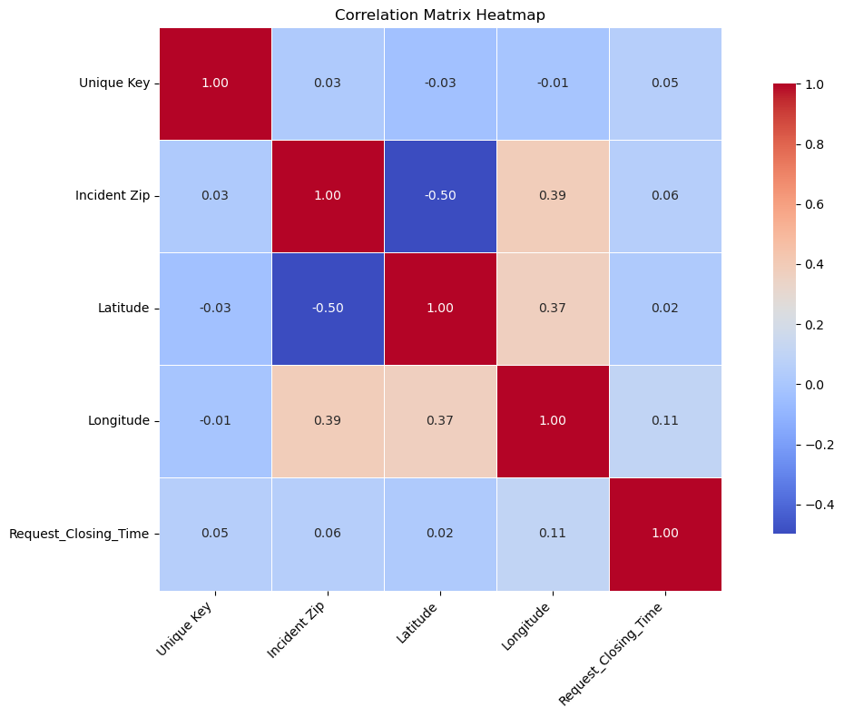

```python
import pandas as pd
import numpy as np
import seaborn as sns
import matplotlib.pyplot as plt

# Filter only numeric columns
numeric_df = df.select_dtypes(include=[np.number])

# Calculate correlation matrix

corr_matrix = numeric_df.corr()

# Display correlation matrix in text format
print("\nCorrelation matrix:")
print(corr_matrix)

# Plot the heatmap
plt.figure(figsize=(12, 8))
sns.heatmap(corr_matrix, annot=True, fmt=".2f", cmap='coolwarm', square=True, linewidths=0.5, cbar_kws={"shrink": .8})
plt.title("Correlation Matrix Heatmap")
plt.xticks(rotation=45, ha='right')
plt.yticks(rotation=0)
plt.tight_layout()
plt.show()
```

4. Data EXploration

The objective of this task is to derive meaningful insights from the dataset through visualizations. By analyzing the "Request_Closing_Time" across different complaint types and locations, we aim to identify patterns and trends in the data. The visual representation of these insights will help in understanding which complaint types take longer to resolve and how location may affect the resolution times. The goal is to provide a clear, visual interpretation of the relationship between complaint types, request closing times, and locations, enabling informed decision-making.

1. Four major insights through visualization that I have come up after data mining.

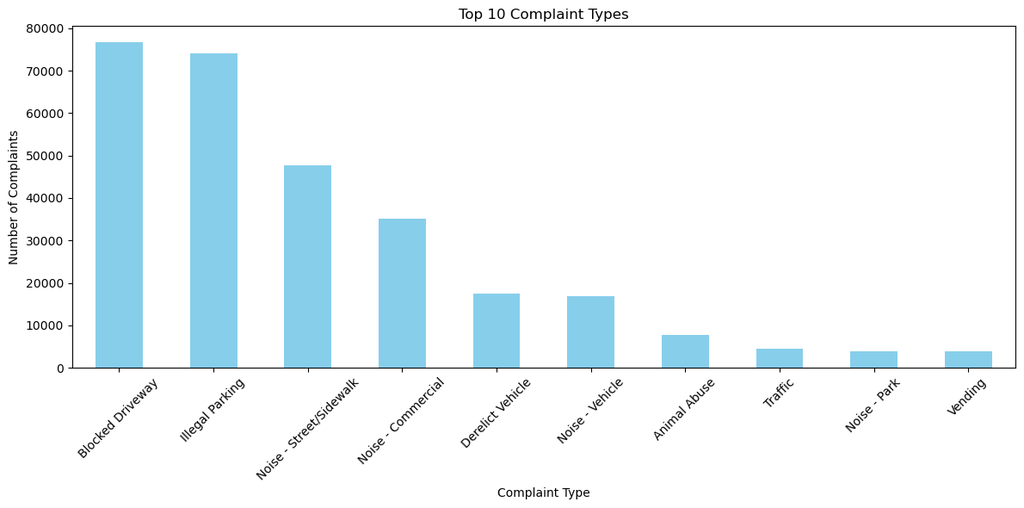

```python
# --- Insight 1: Most Common Complaint Types ---
plt.figure(figsize=(12, 6))
df['Complaint Type'].value_counts().head(10).plot(kind='bar', color='skyblue')
plt.title("Top 10 Complaint Types")
plt.ylabel("Number of Complaints")
plt.xticks(rotation=45)
plt.tight_layout()
plt.show()
```

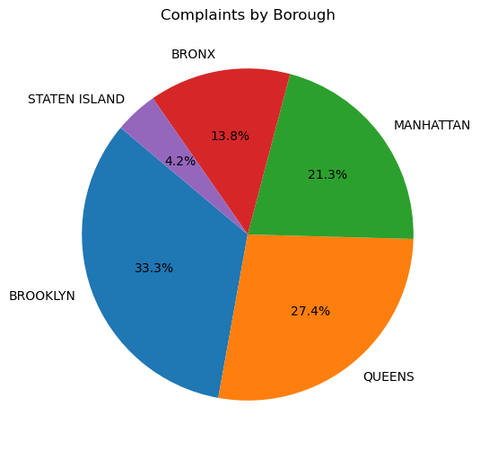

```python
# --- Insight 2: Complaints by Borough ---
plt.figure(figsize=(8, 6))
df['Borough'].value_counts().plot(kind='pie', autopct='%1.1f%%', startangle=140)
plt.title("Complaints by Borough")
plt.ylabel("")
plt.show()
```

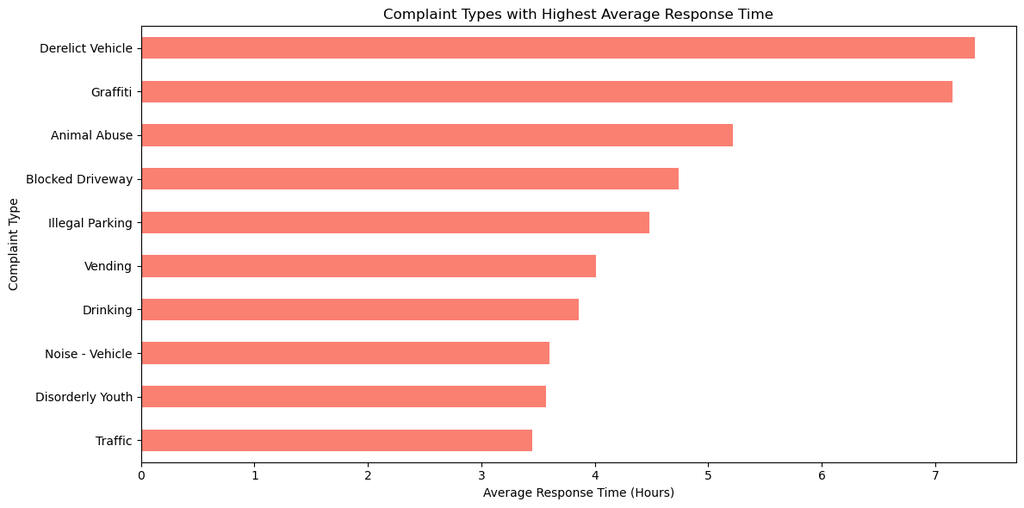

```python
# --- Insight 3: Avg Response Time by Complaint Type ---
avg_response = df.groupby('Complaint Type')['Request_Closing_Time'].mean().sort_values(ascending=False).head(10)
plt.figure(figsize=(12, 6))
avg_response.plot(kind='barh', color='salmon')
plt.xlabel("Average Response Time (Hours)")
plt.title("Complaint Types with Highest Average Response Time")
plt.gca().invert_yaxis()
plt.tight_layout()
plt.show()
```

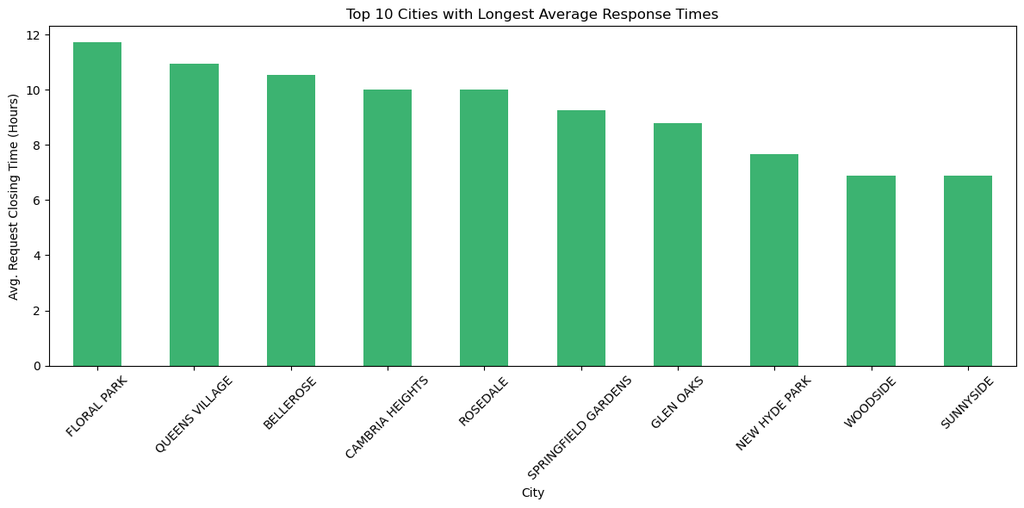

```python
# --- Insight 4: Avg Response Time by City ---
city_response = df.groupby('City')['Request_Closing_Time'].mean().sort_values(ascending=False).head(10)
plt.figure(figsize=(12, 6))
city_response.plot(kind='bar', color='mediumseagreen')
plt.title("Top 10 Cities with Longest Average Response Times")
plt.ylabel("Avg. Request Closing Time (Hours)")
plt.xticks(rotation=45)
plt.tight_layout()
plt.show()
```

The complaint types according to their average “Request_Closing_Time” categorized by various locations

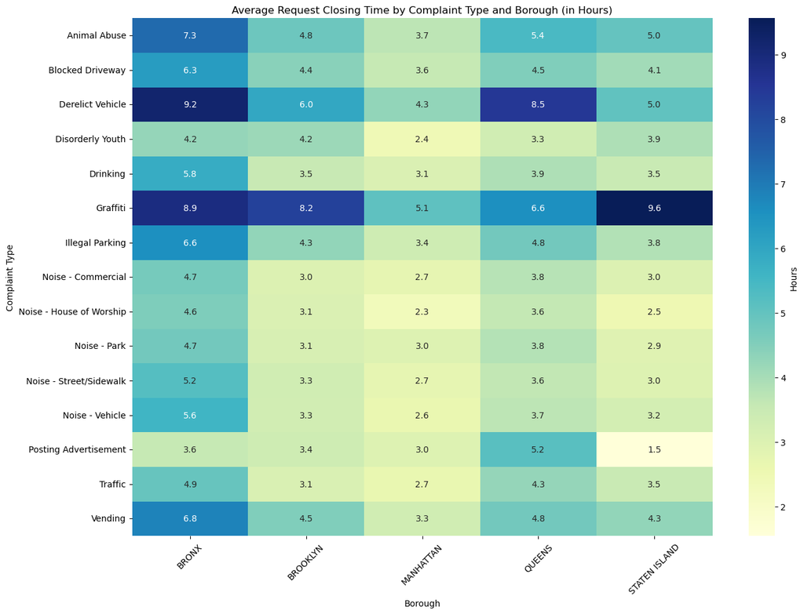

```python
import pandas as pd
import matplotlib.pyplot as plt
import seaborn as sns

# 2. Convert Request_Closing_Time to hours if it's not already in hours
if df['Request_Closing_Time'].max() > 1000:  # If values are very large, likely in seconds
    df['Request_Closing_Time'] = df['Request_Closing_Time'] / 3600  # Convert seconds to hours

# 3. Group and aggregate the data
grouped = df.groupby(['Complaint Type', 'Borough'])['Request_Closing_Time'].mean().reset_index()

# 4. Pivot for heatmap
pivot_table = grouped.pivot(index='Complaint Type', columns='Borough', values='Request_Closing_Time')

# 5. Plot heatmap
plt.figure(figsize=(14, 10))
sns.heatmap(pivot_table, annot=True, fmt=".1f", cmap="YlGnBu", cbar_kws={'label': 'Hours'})
plt.title("Average Request Closing Time by Complaint Type and Borough (in Hours)")
plt.xlabel("Borough")
plt.ylabel("Complaint Type")
plt.xticks(rotation=45)  # Rotate borough names if they're long
plt.tight_layout()
plt.show()
```

5. Statistical Testing

The objective of the hypothesis testing code is to evaluate two key assumptions in the dataset. Test 1 aims to determine whether the average response time differs across various complaint types, using a one-way ANOVA test. The null hypothesis (H₀) assumes that the average response time is the same for all complaint types, while the alternative hypothesis (H₁) suggests they are different. Test 2 seeks to assess whether the type of complaint and location (borough) are related, using a Chi-square test for independence. The null hypothesis (H₀) posits that the complaint type and location are independent, while the alternative hypothesis (H₁) proposes they are related. These tests help in understanding the relationships between different variables in the data.

Test 1: Whether the average response time across complaint types is similar or not Objective: To determine whether the average response time (represented by Request_Closing_Time) is statistically the same across different types of complaints.

Null Hypothesis (H₀): There is no significant difference in the average response time across different complaint types. Alternate Hypothesis (H₁): There is a significant difference in the average response time across different complaint types.

Statistical Test Used: One-way ANOVA (Analysis of Variance)

This test is appropriate because we are comparing the means of a numerical variable (Request_Closing_Time) across more than two independent groups (Complaint Type).

```python
import pandas as pd
import scipy.stats as stats

# Perform one-way ANOVA
f_statistic, p_value = stats.f_oneway(
    *[group['Request_Closing_Time'] for name, group in df.groupby('Complaint Type')]
)

print(f"F-statistic: {f_statistic:.2f}")
print(f"P-value: {p_value:.4f}")
```

```
F-statistic: 578.91
P-value: 0.0000
```

Test Results:

F-statistic: 578.91 P-value: 0.0000

Interpretation: Since the p-value is much less than 0.05, we reject the null hypothesis (H₀).

This means there is strong statistical evidence to conclude that the average response time differs significantly across different complaint types.

In other words, not all complaint types receive the same level of responsiveness — some complaints are likely addressed more quickly, while others take longer.

This implies that the handling of complaints may be influenced by their type, potentially due to differences in urgency, complexity, or available resources for specific issues.

Chi-Square Test Test 2: Whether there is an association between Complaint Type and Borough

Objective: To determine whether the type of complaint is independent of the borough it was reported in — in other words, to test whether certain types of complaints are more common in specific boroughs.

Null Hypothesis (H₀): There is no association between complaint type and borough. (They are independent.) Alternate Hypothesis (H₁): There is an association between complaint type and borough. (They are not independent.)

Statistical Test Used: Chi-Square Test of Independence

This test is appropriate because both Complaint Type and Borough are categorical variables, and we are testing for a relationship between them.

```python
import pandas as pd
from scipy.stats import chi2_contingency

# Create a contingency table
contingency_table = pd.crosstab(df['Complaint Type'], df['Borough'])

# Perform Chi-Square Test
chi2, p_value, dof, expected = chi2_contingency(contingency_table)

print(f"Chi-Square Statistic: {chi2:.2f}")
print(f"P-value: {p_value:.4f}")
print(f"Degrees of Freedom: {dof}")
```

```
Chi-Square Statistic: 73264.62
P-value: 0.0000
Degrees of Freedom: 56
```

Test Results:

Chi-Square Statistic: 73,264.62 P-value: 0.0000 Degrees of Freedom: 56

Interpretation: Since the p-value is much less than 0.05, we reject the null hypothesis (H₀).

This means there is strong statistical evidence to suggest that complaint type and borough are not independent — in other words, there is a significant association between the type of complaint and the borough it was reported in.

This implies that certain complaint types are more (or less) common in specific boroughs, which could be useful for resource allocation or policy decisions.